# Consulting Project

```r
library(car)
library(tidyverse)
library(pander)
nonprofit <- read.csv("../Data/NonProfit.csv")
```

# Description

This data was collected over a span of 4 months from a non-profit organization my parents work with. The organization supports local orphanages by fulfilling donation requests.For this analysis I focused in three main types of needs: Food, Clothing, and Education Supplies. These categories represent the most frequently requested items and provide insights to the organization to see how effectively the organization meets these needs.

With this analysis we will answer the Followign question:

Does the fulfillment rate significantly differ across the three primary categories of needs. Food, Clothing, and Education Supplies for the organization?

We are preforming a one way ANOVA test.

I calculated the fulfillment rate by dividing the request fulfilled by the requests made and multiply it by 100

# Hypothesis

- **Null Hypothesis ($H_0$)**: The average fulfillment rates are the same across the three categories.
- **Alternative Hypothesis ($H_a$)**: At least one category has a significantly different average fulfillment rate.

# Test (ANOVA)

```r
anova_model <- aov(fulfilled_rate ~ need_type, data = nonprofit)


pander(summary(anova_model))
```

Analysis of Variance Model

|  | Df | Sum Sq | Mean Sq | F value | Pr(>F) |
| --- | --- | --- | --- | --- | --- |
| **need_type** | 2 | 87.27 | 43.64 | 0.03898 | 0.9618 |
| **Residuals** | 27 | 30223 | 1119 | NA | NA |

The p-value in this test in 0.9618 which is larger than the significance level

# Graph

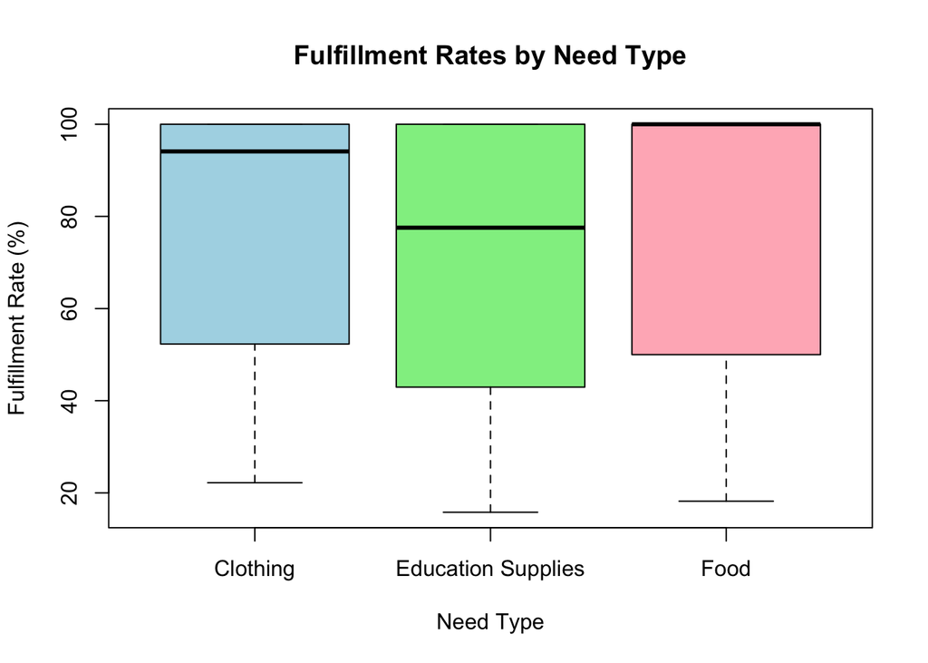

```r
boxplot(fulfilled_rate ~ need_type, data = nonprofit,
        main = "Fulfillment Rates by Need Type",
        xlab = "Need Type",
        ylab = "Fulfillment Rate (%)",
        col = c("lightblue", "lightgreen", "lightpink"))
```

# Assumptions

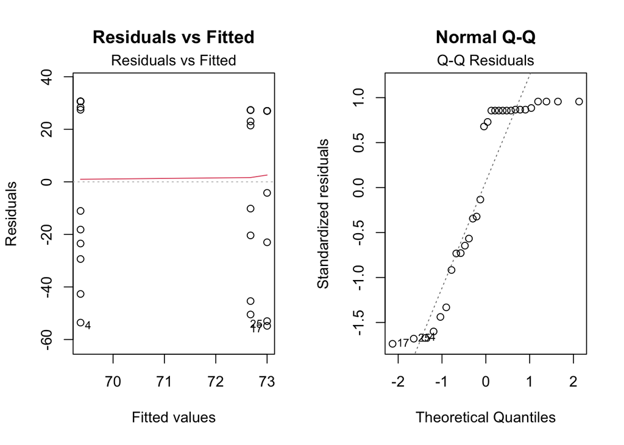

```r
par(mfrow = c(1, 2))


plot(anova_model, which = 1, main = "Residuals vs Fitted")


plot(anova_model, which = 2, main = "Normal Q-Q")
```

# Conclusion

Based on the one way ANOVA test, which gave us a p value of 0.9618, we fail to reject the null hypothesis. There is no significant difference in fulfillment rates acros categories.